# World Climate PCA

Sandra Fogg

1/27/2020

World climatic and environmental variables were obtained from Google Earth Engine and compiled by Zander Venter on Kaggle. Mean values for each country included measurements of rainfall levels, temperature extremes, weather conditions, and topography. Principle components analysis (PCA) is utilized below to better understand patterns of climatic variation across the globe.

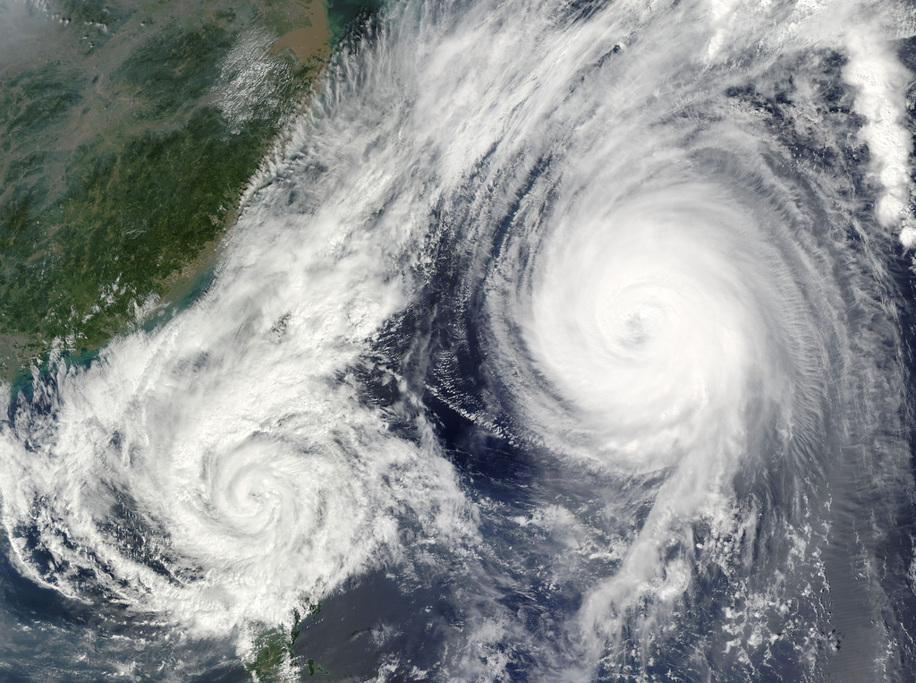

(photo: Pixabay)

### Data Processing

```r
## Clean the Data
# Read in the Data
world_climate_df <- read_csv("world_env_vars.csv")

# Disable Scientific Notation
options(scipen = 999)

# Select the Columns of Interest
# Omit NAs
# Convert Column Headers and Row Strings to Snakecase
# Remove Country Column

climate_clean_df <- world_climate_df %>%
  select(Country, rain_mean_annual, temp_mean_annual, elevation, tree_canopy_cover, cropland_cover) %>%
  na.omit() %>%
  clean_names(case = "snake") %>%
  mutate(country_l = make_clean_names(country, case = "snake")) %>%
  select(-country)
```

### Running PCA

```r
##Select Indicator Variables
climate_subset <- climate_clean_df %>%
  select(rain_mean_annual:cropland_cover)
```

```r
## Run PCA Using `procomp`
climate_pca <- prcomp(climate_subset, scale = TRUE)
```

## Results

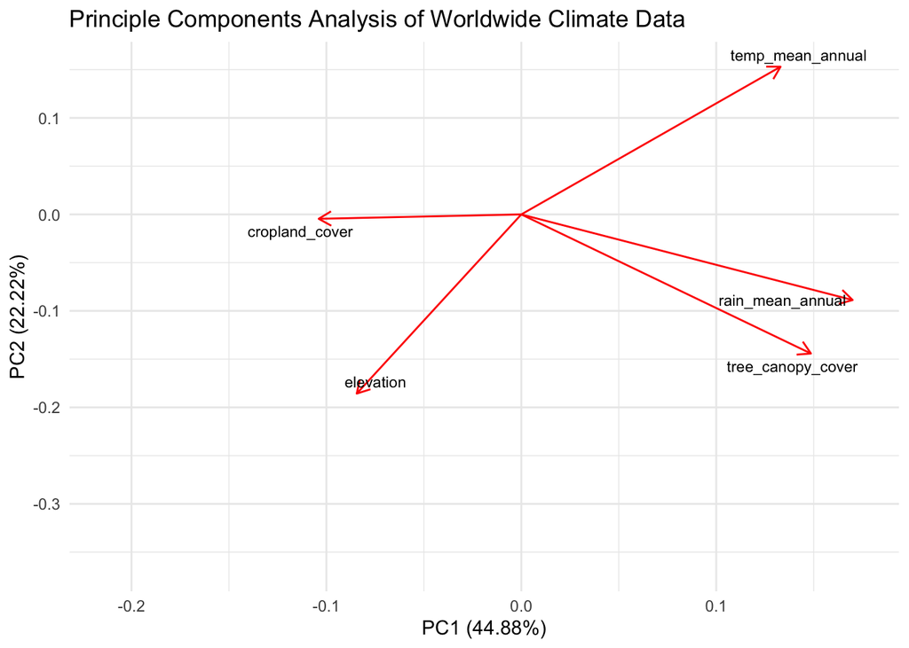

```r
# Plot the Variances
#plot(climate_pca)

# Clean the biplot
clean_biplot <- autoplot(climate_pca,
                         colour = NA,
                       loadings.label.size = 3,
                       loadings.label.colour = "black",
                       loadings.label.repel = TRUE,
                       loadings.label = TRUE) +
  theme_minimal() +
  labs(title = "Principle Components Analysis of Worldwide Climate Data", vars)

clean_biplot
```

Examination of the produced biplot reveals several correlations within worldwide climatic variables. First, it is notable that tree canopy cover and mean levels of rain are positively correlated. This makes sense, as evapotranspiration from plants increases humidity levels, and therefore rain. That is why many dense forests, like tropical and temperature rainforests, have such high levels of precipitation. It also is evident that cropland cover and tree canopy cover are negatively correlated. This is intuitive, as cropland and tree canopy cannot occur simultaneously in the same location. Another intuitive correlation is the negative correlation between mean annual temperature and elevation. Temperature decreases significantly with increasing altitude, which is why this is expected.